# Case Based Reasoning: Cox-Beta-Model

Dr. Simon Müller

2018-06-10

## Initialization

In the first example, we use the Cox-Model and the `ovarian` data set from the `survival` package. In the first step we initialize the R6 data object.

```r
library(tidyverse)
library(survival)
library(CaseBasedReasoning)
ovarian$resid.ds <- factor(ovarian$resid.ds)
ovarian$rx <- factor(ovarian$rx)
ovarian$ecog.ps <- factor(ovarian$ecog.ps)

# initialize R6 object
coxBeta <- CoxBetaModel$new(Surv(futime, fustat) ~ age + resid.ds + rx + ecog.ps)
```

All cases with missing values in the learning and end point variables are dropped (`na.omit`) and the reduced data set without missing values is saved internally. You get a text output on how many cases were dropped. `character` variables will be transformed to `factor`.

## Similar Cases

After the initialization, we may want to get for each case in the query data the most similar case from the learning data.

```r
n <- nrow(ovarian)
trainID <- sample(1:n, floor(0.8 * n), F)
testID <- (1:n)[-trainID]

# fit model
ovarian[trainID, ] %>%
  coxBeta$fit()
```

```
## Dropped cases with missing values: 0
## Start learning...
## Learning finished in: 0.49 seconds.
```

```r
# get similar cases
ovarian[trainID, ] %>%
  coxBeta$get_similar_cases(queryData = ovarian[testID, ], k = 3) -> matchedData
```

```
## Start caclulating similar cases...
```

```
## Similar cases calculation finished in: 0.19 seconds.
```

```r
knitr::kable(head(matchedData))
```

[output not shown]

**Note 1:** In the initialization step, we dropped all cases with missing values in the variables of `data` and `endPoint`. So, you need to make sure that NA handling is done by you.

### Distance Matrix

Alternatively, you may just be interested in the distance matrix, then you go this way:

```r
ovarian %>%
  coxBeta$calc_distance_matrix() -> ditMatrix
```

```
## Start calculating distance matrix...
## Distance matrix calculation finished in: 0.01 seconds.
```

`coxBeta$calc_distance_matrix()` calculates the full distance matrix. This matrix the dimension: cases of data versus cases of query data. If the query dataset is bot available, this functions calculates a n times n distance matrix of all pairs in data. The distance matrix is saved internally in the *CoxBetaModel* object: `coxBeta$distMat`.

## Check Proportional Hazard Assumption:

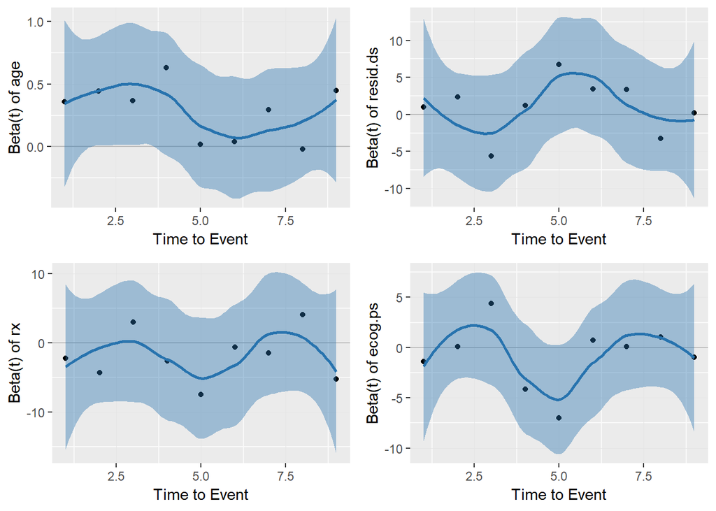

```r
pp <- coxBeta$check_ph()
pp
```